# PISA 2012 Data Exploration

## by John Platter

## Investigation Overview

> I have gleaned a number of insights related to the interactions of student achievement in math, wealth distribution, weekly math education minutes, and a number of other variables. I hope to provide you with the same a-ha moments I had through the use of clear visuals that communicate these findings free from distractions.

## Dataset Overview

> The PISA 2012 is a massive standardized test of Reading, Science and Math given to 15 year old students across 66 different countries. The data also includes a thorough survey of more than 400 attributes. I focused on a few that interested me and came to surprising conclusions as well as conclusions that resonated with my own personal understanding of the world.

## Distribution of Wealth Across the PISA dataset

> The world has a great variety of income levels. Generally, wealth has a left skew, meaning there are a lot more people who have less than people who have a lot. Also, observe the multi-modal spikeyness of the distribution showing clusters of countries who have similar amounts of wealth. Note 0 is the global measure of center and the ticks show deviations left and right of 0.

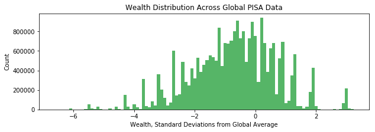

```python
bin_size=.1
plt.figure(figsize=(10,3))
plt.hist(interest_subset['WEALTH'], weights=interest_subset.W_FSTUWT, color=world_color,
             bins=np.arange(interest_subset['WEALTH'].min(), interest_subset['WEALTH'].max()+bin_size, bin_size))
plt.title(f"Wealth Distribution Across Global PISA Data")
plt.ylabel('Count')
plt.xlabel('Wealth, Standard Deviations from Global Average')
```

## Average Wealth Comparisons by Country

> Here is a breakdown of the average wealth reported by students on the PISA survey section broken down by country.

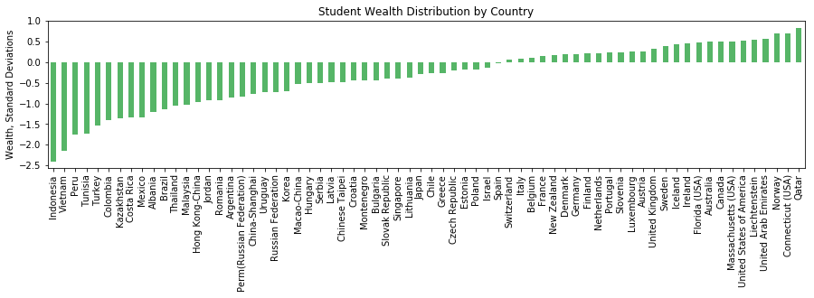

```python
interest_subset.groupby('CNT').mean().WEALTH.sort_values(ascending=True).plot(kind='bar',
                                                                              figsize=(15,3),
                                                                              title='Student Wealth Distribution by Country',
                                                                              color=world_color);
plt.ylabel('Wealth, Standard Deviations');
plt.xlabel('');
```

## Categorical Correlations with Wealth

> Notice how most of the variables leave the wealth distribution unchanged, but `GRADE` shows clear positive interaction with wealth. `GRADE` is the student's grade compared to where the average 15 year old is in their country.

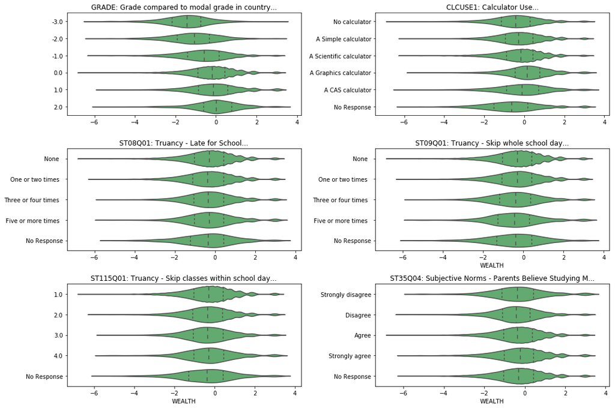

```python
interest_subset_remove_cats=interest_subset[~((interest_subset.GRADE=='3.0')|(interest_subset.GRADE=='No Response'))].copy()
interest_subset_remove_cats.GRADE=interest_subset_remove_cats.GRADE.cat.remove_unused_categories()
j=0
plt.figure(figsize=(15,10))
for i in range(6):

    plt.subplot(3, 2, i+1)
    current=interest_subset_remove_cats.columns[i+1]
    sb.violinplot(data=interest_subset_remove_cats, y=interest_subset_remove_cats[current],
                  x=interest_subset_remove_cats.WEALTH,inner='quartile', color=world_color)
    plt.title('{}: {}...'.format(current,df_key.T[current].values[0][:45]))
    plt.ylabel('')
    if i not in [3,4,5,12,13,14]:#choose some plots to remove the x label, since it is shared among all the facets
        plt.xlabel('')

plt.tight_layout()
```

# Wealth, Achievement, and Grade

> This plot demonstrates how Wealth, Achievement and Grade vary, first on one plot, then faceted by grade. Notice how low grades occupy the bottom left of the graph, demonstrating lower achievement and lower wealth.

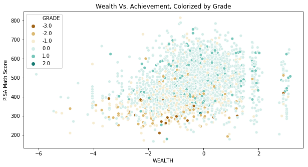

```python
plt.figure(figsize=(10,5))
sb.scatterplot(data=interest_subset_remove_cats.sample(3000),
            x='WEALTH', y='PV1MATH', hue='GRADE', palette=sb.color_palette('BrBG'))
plt.ylabel('PISA Math Score');
plt.title('Wealth Vs. Achievement, Colorized by Grade')
```

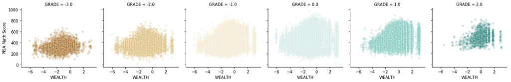

```python
interest_subset_remove_cats.GRADE=interest_subset_remove_cats.GRADE.cat.remove_unused_categories()
g=sb.FacetGrid(data=interest_subset_remove_cats,
                col='GRADE', hue='GRADE',
                palette=sb.color_palette('BrBG',interest_subset.GRADE.nunique()-1),
                col_wrap=6)
g.map(sb.scatterplot, 'WEALTH', 'PV1MATH',alpha=.2,)
g.axes[0].set_ylabel('PISA Math Score');
```

# Achievement Distribution: World, USA, Finland

> This graph shows how Finland's math score distribution is significantly better than both the World and the US score distributions

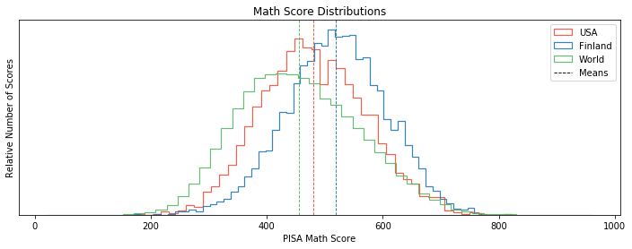

```python
fig,ax=plt.subplots(figsize=(12,4))
#usa dist
sb.distplot(df_usa['PV1MATH'], kde=False, ax=ax, label="USA", color=usa_color,
            hist_kws={'weights':df_usa['W_FSTUWT'].values,
                      'histtype':"step",
                      'density':True});
#usa mean line
usa_mean_math=(df_usa['PV1MATH']*df_usa['W_FSTUWT']).sum()/df_usa['W_FSTUWT'].sum()
plt.axvline(usa_mean_math, linestyle='dashed',color=usa_color, linewidth=.9)

#finland dist
sb.distplot(df_finland['PV1MATH'], kde=False, ax=ax, label="Finland", color=finland_color,
            hist_kws={'weights':df_finland['W_FSTUWT'].values,
                      'histtype':"step",
                      'density':True});
#finland mean line
fin_mean_math=(df_finland['PV1MATH']*df_finland['W_FSTUWT']).sum()/df_finland['W_FSTUWT'].sum()
plt.axvline(fin_mean_math, linestyle='dashed',color=finland_color, linewidth=.9)

#world dist
sb.distplot(interest_subset['PV1MATH'], kde=False, ax=ax, label="World", color=world_color,
            hist_kws={'weights':interest_subset['W_FSTUWT'].values,
                      'histtype':"step",
                      'density':True})
#world mean line
world_mean_math=(interest_subset['PV1MATH']*interest_subset['W_FSTUWT']).sum()/interest_subset['W_FSTUWT'].sum()
plt.axvline(world_mean_math, linestyle='dashed',color=world_color, linewidth=.9)

plt.setp(ax.patches, linewidth=1.2, alpha=.9)#change linewidths of the step type histograms, which are of type patch, not type line!
my_legend=plt.legend()

legend_elements = my_legend.get_patches()+[plt.Line2D([0],[0],color='black', linewidth=.9, linestyle='dashed')]#get current elements and add the black dashed line
legend_labels = ['USA','Finland','World','Means']
plt.legend(legend_elements,legend_labels)
plt.xlabel('PISA Math Score')
plt.ylabel('Relative Number of Scores')
plt.yticks([])
plt.title("Math Score Distributions");
#plt.hist()
```

# USA vs Finland Math Achievement, by Category

> This final plot examines how Students in the US and Finland did on their math test grouped by how they answered their survey questions. I love noticing the small differences between the red and blue lines, as these each tell interesting stories about students in the perspective countries

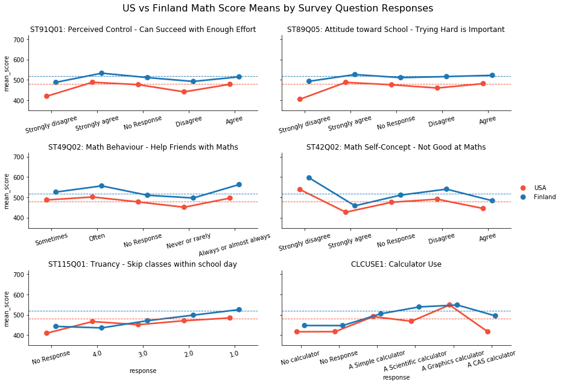

```python
usa_mean_math=(df_usa['PV1MATH']*df_usa['W_FSTUWT']).sum()/df_usa['W_FSTUWT'].sum()
fin_mean_math=(df_finland['PV1MATH']*df_finland['W_FSTUWT']).sum()/df_finland['W_FSTUWT'].sum()

def pointplot(x,y,hue,**kwargs):
    sb.pointplot(x=x,y=y,hue=hue,**kwargs)
g=sb.FacetGrid(data=cat_means[cat_means.category.isin(['ST91Q01','ST89Q05','ST49Q02','ST42Q02','ST115Q01','CLCUSE1'])],
               col='category',aspect=2,
               col_wrap=2, sharex=False, sharey=True,
               ylim=(200,750),
              );
ax=g.map(pointplot, 'response', 'mean_score', 'CNT',palette={'USA':usa_color,'Finland':finland_color},
         dodge=0.2, linestyles='-', xerr='std_dev');

for ax in g.axes.flat:
    labels=ax.get_xticklabels()
    title=ax.get_title().replace('category = ', '')
    ax.set_xticklabels(labels,rotation=15)
    ax.set_title(f'{title}: {df_key.T[title].values[0]}')
    ax.set_ylim([350,720])
    ax.axhline(fin_mean_math, linestyle='dashed', color=finland_color, linewidth=.9)
    ax.axhline(usa_mean_math, linestyle='dashed', color=usa_color, linewidth=.9)

plt.tight_layout()
g.fig.suptitle("US vs Finland Math Score Means by Survey Question Responses", size=16);
g.fig.subplots_adjust(top=.9);
g.add_legend();
```